# Exploring temporal data

## Introducing dates, times and time series

## Date and time types and formats

- Dates and times can be represented in different ways
- There are lots of different date and time formats
- A date-time is a data type that includes a date and a time
- It can be frustrating getting your times into the right format
- I’ll use R packages `lubridate` and `base`

## Time series data

- Events occurring sequentially through time can be thought of as time series
- These could be weather measurements, purchases, football match outcomes, even locations in space

## In this lecture

- We will first go through different types of time and date classes
- Then we will do some visualisation and exploration of time series

## Dates, times and date-times

### Battle of the libraries: `base` vs `lubridate`

- in `base` R dates and date-times have a special class called `posixCT`

```r
# date-time including time zone
Sys.time()
```

```
## [1] "2021-03-30 14:06:31 SAST"
```

```r
# date in current time zone
Sys.Date()
```

```
## [1] "2021-03-30"
```

## Dates, times and date-times

### Battle of the libraries: `base` vs `lubridate`

- `lubridate` is a tidyverse package
- You can do what we did above using lubridate

```r
# date-time including time zone
now()  # lubridate
```

```
## [1] "2021-03-30 14:06:31 SAST"
```

```r
# date in current time zone
today()  # lubridate
```

```
## [1] "2021-03-30"
```

## Reading in date information

- This can be harder than it should be, especially when using tab- or comma-delimited formats

```r
wind_data <- read.csv("data/wind_direction.csv")
head(wind_data, n = 3)
```

```
##    Location       Date Wind_direction_degrees
## 1 Cape Town 06/02/2020                    150
## 2 Cape Town 07/02/2020                    136
## 3 Cape Town 08/02/2020                    162
```

```r
class(wind_data$Date)
```

```
## [1] "factor"
```

## Changing the date format with `base`

- As you can see, R thinks the date column is a factor
- In `base` R you often need to specify the “Unix Epoch”  
  1970-01-01 in the origin argument

```r
my_base_date <- as.Date(as.character(wind_data$Date),
                        tryFormats = c("%d-%m-%Y", "%d/%m/%Y"),
                        origin="1970-01-01")
head(my_base_date, n=4)
```

```
## [1] "2020-02-06" "2020-02-07" "2020-02-08" "2020-02-09"
```

```r
class(my_base_date)
```

```
## [1] "Date"
```

## Changing the date format with `lubridate`

- `lubridate` syntax is intuitive and compact

```r
class(wind_data$Date)
```

```
## [1] "factor"
```

```r
my_lbdt_date <- dmy(as.character(wind_data$Date))
head(my_lbdt_date, n = 4)
```

```
## [1] "2020-02-06" "2020-02-07" "2020-02-08" "2020-02-09"
```

```r
class(my_lbdt_date)
```

```
## [1] "Date"
```

## Pitfalls

- The `as.character` bit is important!

```r
as.Date(wind_data$Date,
        format="%Y-%m-%d", tz="SAST",
        origin="1970-01-01")
```

```
## [1] NA NA NA NA NA NA NA
```

```r
as.Date(as.character(wind_data$Date),
        format="%d/%m/%Y", tz="SAST",
        origin="1970-01-01")
```

```
## [1] "2020-02-06" "2020-02-07" "2020-02-08" "2020-02-09"
"2020-02-10"
## [6] "2020-02-11" "2020-02-12"
```

## Pitfalls

- If you tell R the object contains times it will make them up

```r
my_fake_dt <- as.POSIXct(my_lbdt_date, format = "%Y-%m-%d", tz = "SAST",
    origin = "1970-01-01 00:00:00")
head(my_fake_dt, n = 4)
```

```
## [1] "2020-02-06 02:00:00 SAST" "2020-02-07 02:00:00 SAST"
## [3] "2020-02-08 02:00:00 SAST" "2020-02-09 02:00:00 SAST"
```

## Pitfalls

- You can’t add a timezone to a date
- Even if you do add it, like we did, it won’t show up

```r
my_base_date <- as.Date(as.character(wind_data$Date),
                        tryFormats = c("%d-%m-%Y", "%d/%m/%Y"),
                        origin="1970-01-01",tz="SAST")
head(my_base_date, n=4)
```

```
## [1] "2020-02-06" "2020-02-07" "2020-02-08" "2020-02-09"
```

## Pitfalls

- Format mistakes
- The format argument must match the *current* format of the date

```r
as.Date(as.character(wind_data$Date), format = "%Y-%m-%d", tz = "SAST",
    origin = "1970-01-01")
```

```
## [1] NA NA NA NA NA NA NA
```

```r
as.Date(as.character(wind_data$Date), format = "%Y/%m/%d", tz = "SAST",
    origin = "1970-01-01")
```

```
## [1] "0006-02-20" "0007-02-20" "0008-02-20"
```

## Many format options…

```r
ymd("2020-01-31")
```

```
## [1] "2020-01-31"
```

```r
mdy("January 31st, 2020")
```

```
## [1] "2020-01-31"
```

```r
dmy("31-Jan-2020")
```

```
## [1] "2020-01-31"
```

```r
ymd(20200131)
```

```
## [1] "2020-01-31"
```

## Date-times can also have lots of formats

```r
ymd_hms("2020-01-31 14:09:21")
```

```
## [1] "2020-01-31 14:09:21 UTC"
```

```r
mdy_hm("01/31/2020 06:09")
```

```
## [1] "2020-01-31 06:09:00 UTC"
```

```r
mdy_h("01/31/2020 06")
```

```
## [1] "2020-01-31 06:00:00 UTC"
```

## Exercise 1

In `01-ts-exercise.R`.

Use the appropriate `lubridate` function to parse each of the following dates:

```
d1 <- "January 1, 2010"
d2 <- "2015-Mar-07"
d3 <- "06-Jun-2017"
d4 <- c("August 19 (2015)", "July 1 (2015)")
d5 <- "12/30/14" # Dec 30, 2014
```

## Time zones

- You can specify a time zone up-front

```r
ymd_hms("2020-01-31 14:09:21", tz = "Africa/Johannesburg")
```

```
## [1] "2020-01-31 14:09:21 SAST"
```

- Or add it later

```r
mytime <- ymd_hms("2020-01-31 14:09:21")
with_tz(mytime, tzone = "Africa/Johannesburg")
```

```
## [1] "2020-01-31 16:09:21 SAST"
```

## Once you have a date, time or date-time object

- You can extract elements from it, like the date

```r
womensday <- ymd_hms("2020-08-09-12-30-30", tz = "GMT")
womensday
```

```
## [1] "2020-08-09 12:30:30 GMT"
```

```r
date(womensday)
```

```
## [1] "2020-08-09"
```

```r
month(womensday)
```

```
## [1] 8
```

```r
# Is it a leap year?
leap_year(womensday)
```

```
## [1] TRUE
```

## Once you have a date, time or date-time object

- Or elements of the time

```r
hour(womensday)
```

```
## [1] 12
```

```r
minute(womensday)
```

```
## [1] 30
```

```r
second(womensday)
```

```
## [1] 30
```

## Once you have a date, time or date-time object

- Or elements of the calendar date

```r
mday(womensday)
```

```
## [1] 9
```

```r
wday(womensday, label = TRUE)
```

```
## [1] Sun
## Levels: Sun < Mon < Tue < Wed < Thu < Fri < Sat
```

```r
yday(womensday)
```

```
## [1] 222
```

## You can also create datetimes from their components

```r
temp_data <- read.csv("data/temperature.csv")
head(temp_data, n = 3)
```

```
##    Location Temperature Day Month Year Hour Minute Second
## 1 Cape Town        20.1   6     2 2020    8     30     41
## 2 Cape Town        22.9   6     2 2020    9     10      2
## 3 Cape Town        23.6   6     2 2020    9     49     23
```

## You can also create datetimes from their components

```r
temp_data %>% select(Year, Month, Day, Hour, Minute, Second) %>%
    mutate(DateTime = make_datetime(Year, Month, Day, Hour, Minute,
        Second))
```

```
##   Year Month Day Hour Minute Second            DateTime
## 1 2020     2   6    8     30     41 2020-02-06 08:30:41
## 2 2020     2   6    9     10      2 2020-02-06 09:10:02
## 3 2020     2   6    9     49     23 2020-02-06 09:49:23
## 4 2020     2   6   10     28     44 2020-02-06 10:28:44
## 5 2020     2   6   11      8      5 2020-02-06 11:08:05
## 6 2020     2   6   11     47     26 2020-02-06 11:47:26
## 7 2020     2   6   12     26     47 2020-02-06 12:26:47
```

## Rounding dates

- Sometimes you might want to round a date

```r
floor_date(now(), unit = "minutes")
```

```
## [1] "2021-03-30 14:06:00 SAST"
```

```r
ceiling_date(now(), unit = "minutes")
```

```
## [1] "2021-03-30 14:07:00 SAST"
```

## Exercise 2

In `02-ts-exercise.R`.

1. Open the `flights` dataset
2. Use `make_datetime()` to combine the year, month, day, hour and minute variables into a single variable containing the departure time.
3. Remove the variables you used to make up the departure variable.
4. Make a line plot of the average departure delay within each hour of the day.

## Time spans

- Durations: exact number of seconds between events
- Periods: track clock time between events in human units like weeks and months
- Intervals: have a start and an end point

## Durations

- Durations: a time span in exact number of seconds
- Subtracting two dates can give confusing results
- Durations only measure time in seconds

How old is Kanye West?

```r
kw_age <- today() - ymd(19770608)
kw_age
```

```
## Time difference of 16001 days
```

```r
as.duration(kw_age)
```

```
## [1] "1382486400s (~43.81 years)"
```

## Durations

How old will Kanye West be next week?

```r
kw_age + dweeks(1)
```

```
## Time difference of 1383091200 secs
```

```r
as.duration(kw_age + dweeks(1))
```

```
## [1] "1383091200s (~43.83 years)"
```

## Periods

- Periods: accurately track clock time despite human time constructs like leap seconds, leap years and daylight savings

```r
months(8) + days(12) + seconds(3)
```

```
## [1] "8m 12d 0H 0M 3S"
```

```r
ymd("2020-01-01") + dyears(1)
```

```
## [1] "2020-12-31 06:00:00 UTC"
```

```r
# > [1] '2016-12-31 06:00:00 UTC'
ymd("2020-01-01") + years(1)
```

```
## [1] "2021-01-01"
```

```r
# > [1] '2017-01-01'
```

## Intervals

- Intervals: have a start and an end point

```r
# Create an interval in time
lunch <- paste(as.character(today()), "12-30-05")
lunchtime <- ymd_hms(lunch, tz = "Africa/Johannesburg")
lunchtime
```

```
## [1] "2021-03-30 12:30:05 SAST"
```

```r
time_since_lunch <- lubridate::interval(lunchtime, now())
time_since_lunch
```

```
## [1] 2021-03-30 12:30:05 SAST--2021-03-30 14:06:32 SAST
```

```r
as.duration(time_since_lunch)
```

```
## [1] "5787.50559997559s (~1.61 hours)"
```

## Intervals

- Intervals are made up of two dates

```r
# Access the start of an interval
start <- int_start(time_since_lunch)
start
```

```
## [1] "2021-03-30 12:30:05 SAST"
```

```r
# Access the end point of an interval
end <- int_end(time_since_lunch)
end
```

```
## [1] "2021-03-30 14:06:32 SAST"
```

## Exercise 3

In `03-ts-exercise.R`.

Write a function that given your birthday (as a date), returns how old you are in years.

## Explorating time series through visualisation

- Packages `tsibble`, `feasts`, `brolgar`, `dygraphs`
- Datasets:
  - dolphin sightings at Cape Vidal, KZN
  - wage data from the `brolgar` package
  - purchase data from [Kaggle](https://www.kaggle.com/c/acquire-valued-shoppers-challenge)
- What is a time series?
  - a list of numbers of interest, indexed by the times those numbers were recorded
  - there is a special type of dataframe in `R` for time series, a `tsibble`

## Dolphin sightings

- Hourly number of dolphin sightings

```r
load("data/hourly_dolphin_counts.RData")
head(hourly_counts, n = 5)
```

```
## datetime sightability monthkey tideheight dolphin_counts
effort
## 1 1990-06-02 11:00:00 2.5 6 1.24 4 12
## 2 1990-06-03 09:00:00 3.0 6 0.88 7 14
## 3 1990-06-03 10:00:00 3.0 6 1.08 3 13
## 4 1990-06-03 11:00:00 3.0 6 1.19 4 12
## 5 1990-06-03 13:00:00 4.0 6 1.31 6 10
## location
## 1 Cape Vidal
## 2 Cape Vidal
## 3 Cape Vidal
## 4 Cape Vidal
## 5 Cape Vidal
```

## Dolphin sightings

- Weekly number of dolphin sightings
- We only keep date to help us with plotting

```r
weekly_counts <- hourly_counts %>% mutate(week = week(datetime)) %>%
    group_by(week, location) %>% summarise(sum_counts = sum(dolphin_counts),
    sum_effort = sum(effort), mean_sight = mean(sightability),
    date = mean(datetime))
head(weekly_counts, n = 3)
```

```
## # A tibble: 3 x 6
## # Groups: week [2]
## week location sum_counts sum_effort mean_sight date
## <dbl> <chr> <dbl> <dbl> <dbl> <dttm>
## 1 22 Cape Vidal 41 97 3.06 1990-06-03 09:22:30
## 2 22 Richards Bay 18 97 3.06 1990-06-03 09:22:30
## 3 23 Cape Vidal 88 202 3.56 1990-06-07 23:35:17
```

## From dataframe to `tsibble`

```r
weekly_counts <- as_tsibble(x = weekly_counts, key = location,
    index = week, regular = TRUE)
head(weekly_counts)
```

```
## # A tsibble: 6 x 6 [1]
## # Key: location [1]
## # Groups: @ week [6]
## week location sum_counts sum_effort mean_sight date
## <dbl> <chr> <dbl> <dbl> <dbl> <dttm>
## 1 22 Cape Vidal 41 97 3.06 1990-06-03 09:22:30
## 2 23 Cape Vidal 88 202 3.56 1990-06-07 23:35:17
## 3 24 Cape Vidal 180 355 3.66 1990-06-15 05:03:52
## 4 25 Cape Vidal 108 213 3.31 1990-06-20 10:56:40
## 5 26 Cape Vidal 95 201 2.97 1990-06-26 10:56:15
## 6 27 Cape Vidal 164 378 3.45 1990-07-07 05:00:00
```

## Plotting a time series

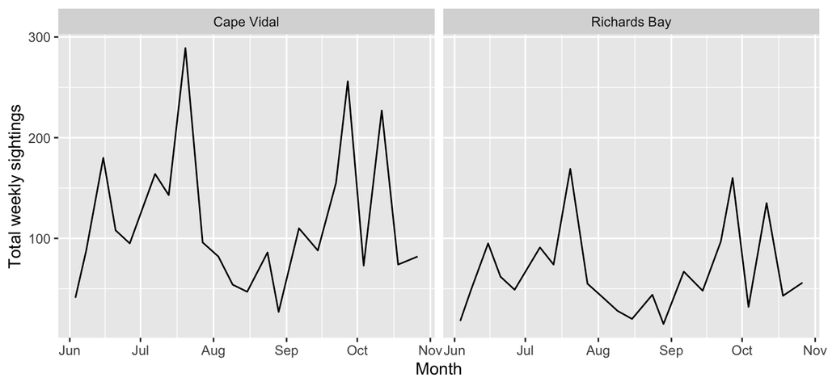

```r
weekly_counts %>% ggplot(aes(x = date, y = sum_counts)) + geom_line() +
    ylab("Total weekly sightings") + xlab("Month") + facet_grid(~location)
```

## Seasonal decomposition

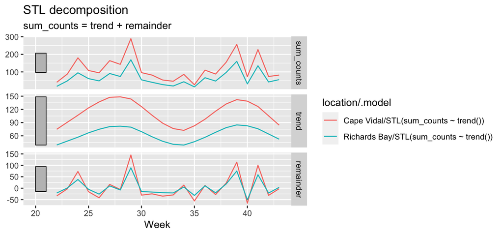

```r
sdecomp <- weekly_counts %>% model(STL(sum_counts ~ trend())) %>%
    components()

autoplot(sdecomp) + xlab("Week")
```

## Exercise 4

In `04-ts-exercise.R`.

Use the tools above to see if there are more purchases made on certain days of the week.

## Individuals through time with `brolgar`

- There is a dataset built into this package about wages

```r
head(wages)
```

```
## # A tsibble: 6 x 9 [!]
## # Key: id [1]
## id ln_wages xp ged xp_since_ged black hispanic
high_grade
## <int> <dbl> <dbl> <int> <dbl> <int> <int> <int>
## 1 31 1.49 0.015 1 0.015 0 1 8
## 2 31 1.43 0.715 1 0.715 0 1 8
## 3 31 1.47 1.73 1 1.73 0 1 8
## 4 31 1.75 2.77 1 2.77 0 1 8
## 5 31 1.93 3.93 1 3.93 0 1 8
## 6 31 1.71 4.95 1 4.95 0 1 8
## # … with 1 more variable: unemploy_rate <dbl>
```

## Individuals through time with `brolgar`

- As you can see it’s a `tsibble` and it was created like this

```
wages <- as_tsibble(x = wages,
                    key = id,
                    index = xp,
                    regular = FALSE)
```

## Individuals through time with `brolgar`

- Really nice functionality for exploring datasets composed of time series from many individuals or groupings, e.g.,
  - individual humans or animals
  - individual locations
  - individual companies
  - individual sports teams
  - …

## Sample a handful of time series

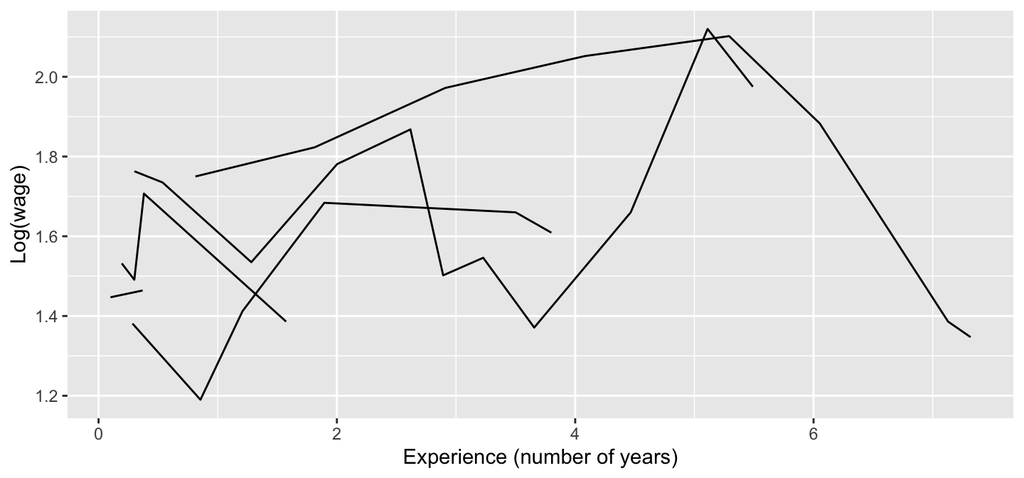

```r
wages %>%
  sample_n_keys(size = 5) %>%
  ggplot(aes(x = xp, y = ln_wages, group = id)) +
  geom_line() +
  labs(y="Log(wage)", x="Experience (number of years)")
```

## Sample a handful of time series

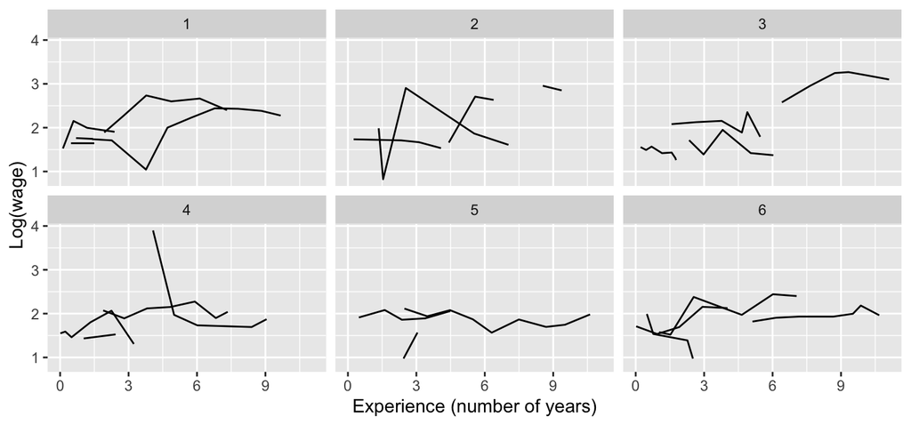

```r
ggplot(wages,
       aes(x = xp, y = ln_wages, group = id)) +
       geom_line() + facet_sample(n_per_facet = 3, n_facets = 6) +
  labs(y="Log(wage)", x="Experience (number of years)")
```

## Exercise 5

In `05-ts-exercise.R`.

Repeat the analysis above for the `ChickWeight` dataset. Look for any interesting patterns in individual chicks.

## Interactive time series plots

```r
weekly_counts %>% dplyr::select(location, week, sum_counts) %>%
  pivot_wider(names_from = location, values_from = sum_counts) %>%
  dygraph() %>% dyOptions(stackedGraph = FALSE) %>%
  dyRangeSelector(height = 20)
```

[interactive chart not shown]

```r
weekly_counts %>% dplyr::select(location, week, sum_counts) %>%
  pivot_wider(names_from = location, values_from = sum_counts) %>%
  dygraph() %>% dyOptions(stackedGraph = TRUE) %>%
  dyRangeSelector(height = 20)
```

[interactive chart not shown]

## Exercise 6

In `06-ts-exercise.R`.

Use the `dygraphs` package to create an interactive plot of weekly total purchases for each brand A, B, C, D

## Reading

- https://r4ds.had.co.nz/dates-and-times.html
- https://cran.r-project.org/web/packages/feasts/vignettes/feasts.html
- https://feasts.tidyverts.org/
- https://www.njtierney.com/post/2019/08/13/introducing-brolgar/